# Economic and Health Effects of Environmental Events

## Summary

In this report, we attempt to determine which weather events cause the greatest economic and population damage across the United States over the time period 1950-2011. The data is taken from NOAA’s storm database and can be downloaded [here](https://d396qusza40orc.cloudfront.net/repdata%2Fdata%2FStormData.csv.bz2). Our hypothesis is that both economic and population damage is increasing over time. By adding up fatalities & injuries and crop damage & property damage, we found this was so. We found that the most devestating event types fell into similar categories. Additionaly, by plotting the damage over time, we discovered that economic damage is increasing at a much faster rate than population damage.

## Data Processing

First, we unzip the file and load the .csv.library

```r
StormData <- read.csv("./repdata-data-StormData.csv.bz2")
```

Next, we will calculate the primary metric by which we will determine damage to population health (fatalities + injuries)

```r
library(dplyr)
StormData <- mutate(StormData,TOTAL_POP_DMG = FATALITIES + INJURIES)
```

We will also calculate the primary metric by which we will calculate economic damage (property damage + crop damage). In order to do this, we need to first convert the exponent columns to numeric values.

There are several different values in both the PROPDMGEXP and CROPDMGEXP columns. We will be using this [method](https://rstudio-pubs-static.s3.amazonaws.com/58957_37b6723ee52b455990e149edde45e5b6.html) for creating the correct exponent values.

```r
StormData$PROPDMGEXP <- gsub("0",1,StormData$PROPDMGEXP,ignore.case = TRUE)
StormData$PROPDMGEXP <- gsub("1",1,StormData$PROPDMGEXP,ignore.case = TRUE)
StormData$PROPDMGEXP <- gsub("2",1,StormData$PROPDMGEXP,ignore.case = TRUE)
StormData$PROPDMGEXP <- gsub("3",1,StormData$PROPDMGEXP,ignore.case = TRUE)
StormData$PROPDMGEXP <- gsub("4",1,StormData$PROPDMGEXP,ignore.case = TRUE)
StormData$PROPDMGEXP <- gsub("5",1,StormData$PROPDMGEXP,ignore.case = TRUE)
StormData$PROPDMGEXP <- gsub("6",1,StormData$PROPDMGEXP,ignore.case = TRUE)
StormData$PROPDMGEXP <- gsub("7",1,StormData$PROPDMGEXP,ignore.case = TRUE)
StormData$PROPDMGEXP <- gsub("8",1,StormData$PROPDMGEXP,ignore.case = TRUE)
StormData$PROPDMGEXP <- gsub("\\+",1,StormData$PROPDMGEXP,ignore.case = TRUE)

StormData$PROPDMGEXP <- gsub("\\-",0,StormData$PROPDMGEXP,ignore.case = TRUE)
StormData$PROPDMGEXP <- gsub("\\?",0,StormData$PROPDMGEXP,ignore.case = TRUE)

StormData$PROPDMGEXP <- gsub("H",2,StormData$PROPDMGEXP,ignore.case = TRUE)
StormData$PROPDMGEXP <- gsub("K",3,StormData$PROPDMGEXP,ignore.case = TRUE)
StormData$PROPDMGEXP <- gsub("M",6,StormData$PROPDMGEXP,ignore.case = TRUE)
StormData$PROPDMGEXP <- gsub("B",9,StormData$PROPDMGEXP,ignore.case = TRUE)

StormData$CROPDMGEXP <- gsub("0",1,StormData$CROPDMGEXP,ignore.case = TRUE)
StormData$CROPDMGEXP <- gsub("2",1,StormData$CROPDMGEXP,ignore.case = TRUE)

StormData$CROPDMGEXP <- gsub("\\?",0,StormData$CROPDMGEXP,ignore.case = TRUE)

StormData$CROPDMGEXP <- gsub("H",2,StormData$CROPDMGEXP,ignore.case = TRUE)
StormData$CROPDMGEXP <- gsub("K",3,StormData$CROPDMGEXP,ignore.case = TRUE)
StormData$CROPDMGEXP <- gsub("M",6,StormData$CROPDMGEXP,ignore.case = TRUE)
StormData$CROPDMGEXP <- gsub("B",9,StormData$CROPDMGEXP,ignore.case = TRUE)

StormData$CROPDMGEXP <- as.numeric(StormData$CROPDMGEXP)
StormData$PROPDMGEXP <- as.numeric(StormData$PROPDMGEXP)

StormData$PROPDMGEXP<-replace(StormData$PROPDMGEXP,is.na(StormData$PROPDMGEXP),0)
StormData$CROPDMGEXP<-replace(StormData$CROPDMGEXP,is.na(StormData$CROPDMGEXP),0)
```

Then, we will calculate the total economic damage ((PROPDMG * 10^PROPDMGEXP) + (CROPDMG * 10^CROPDMGEXP)).

```r
StormData <- mutate(StormData,TOTAL_ECON_DMG = (PROPDMG * 10^PROPDMGEXP) + (CROPDMG * 10^CROPDMGEXP))
```

Finally, we’ll group by EVTYPE

```r
StormData <- group_by(StormData,EVTYPE)
```

## Results

Tornadoes have the highest human cost by far. Total fatalities + injuries surpass the next highest event (Excessive Heat) by more than 10x. In addition, two other wind-related events appear in the top 10.

```r
POP_DMG <- summarise(StormData,TOTAL_FATALITIES = sum(FATALITIES),TOTAL_INJURIES = sum(INJURIES),TOTAL_POP_DMG = sum(TOTAL_POP_DMG))
arrange(POP_DMG,desc(TOTAL_POP_DMG))
```

```
## Source: local data frame [985 x 4]
##
##               EVTYPE TOTAL_FATALITIES TOTAL_INJURIES TOTAL_POP_DMG
## 1            TORNADO             5633          91346         96979
## 2     EXCESSIVE HEAT             1903           6525          8428
## 3          TSTM WIND              504           6957          7461
## 4              FLOOD              470           6789          7259
## 5          LIGHTNING              816           5230          6046
## 6               HEAT              937           2100          3037
## 7        FLASH FLOOD              978           1777          2755
## 8          ICE STORM               89           1975          2064
## 9  THUNDERSTORM WIND              133           1488          1621
## 10      WINTER STORM              206           1321          1527
## ..               ...              ...            ...           ...
```

While Tornadoes make an appearance in the top 10 events in terms of economic impact, Floods cause almost 3x as much damage. In fact, 6 of the top 10 most economically devastating events are floods or hurricanes (where are a great deal of the damage is caused by flooding).

```r
ECON_DMG <- summarise(StormData,TOTAL_PROP = sum(PROPDMG * 10^PROPDMGEXP), TOTAL_CROP = sum(CROPDMG * 10^CROPDMGEXP), TOTAL_ECON_DMG = sum(TOTAL_ECON_DMG) )
arrange(ECON_DMG,desc(TOTAL_ECON_DMG))
```

```
## Source: local data frame [985 x 4]
##
##               EVTYPE   TOTAL_PROP  TOTAL_CROP TOTAL_ECON_DMG
## 1              FLOOD 144657709807  5661968450   150319678257
## 2  HURRICANE/TYPHOON  69305840000  2607872800    71913712800
## 3            TORNADO  56937163440   414954710    57352118150
## 4        STORM SURGE  43323536000        5000    43323541000
## 5               HAIL  15732269934  3025954653    18758224587
## 6        FLASH FLOOD  16140815218  1421317100    17562132318
## 7            DROUGHT   1046106000 13972566000    15018672000
## 8          HURRICANE  11868319010  2741910000    14610229010
## 9        RIVER FLOOD   5118945500  5029459000    10148404500
## 10         ICE STORM   3944928310  5022113500     8967041810
## ..               ...          ...         ...            ...
```

Finally, let’s look at how Total Economic and Population damage changes over time (on a logarithmic scale).

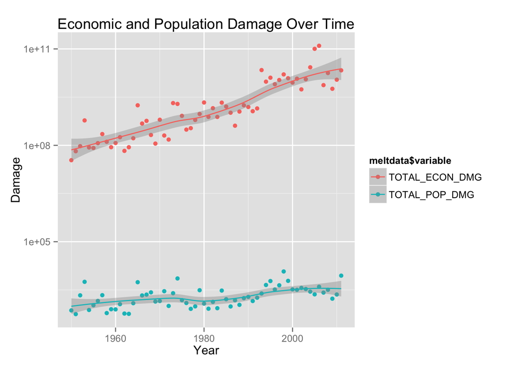

```r
library(reshape2)
library(lubridate)
library(ggplot2)
DMG_BY_YEAR <- mutate(StormData,YEAR = year(strptime(BGN_DATE,format = "%m/%d/%Y %H:%M:%S"))) %>% group_by(YEAR) %>% summarise(TOTAL_ECON_DMG = sum(TOTAL_ECON_DMG),TOTAL_POP_DMG = sum(TOTAL_POP_DMG))

meltdata<-melt(DMG_BY_YEAR,id.vars = "YEAR")

qplot(x = meltdata$YEAR,y = meltdata$value,colour = meltdata$variable, geom = c("point","smooth"),log = "y", xlab = "Year",ylab = "Damage",main = "Economic and Population Damage Over Time")
```

Interestingly, economic damage appears to be increasing at a faster rate than population damage, even when plotted on a logarithmic scale. Obviously, the loss of human life is tragic, but while population damage remained relatively steady, the scale and accelerating rate of economic damage is concerning.